# Categorical variables in SEM

```r
library(lavaan)
library(dplyr)
```

```r
library(DiagrammeR)
library(lavaanPlot)
```

# Intro

This week, we’ll continue using the sem_categorical.dat dataset.

```r
habit <- read.table("sem_categorical.dat", header = FALSE)
head(habit)  # Notice that there are no variable names in this dataset
```

```
##   V1 V2 V3 V4       V5       V6       V7       V8    V9 V10              V11
## 1 49  1  0  1 3.666667 3.333333 3.333333 3.416667 3.500 4.2             4.25
## 2 59  0  1  0 3.000000 4.333333 3.666667 3.250000 2.375 3.0              2.5
## 3 23  0  0  1 3.333333 3.666667 2.333333 3.000000 3.250 3.4              3.5
## 4 26  0  1  1 3.666667 4.666667 4.333333 3.500000 4.000 3.5                4
## 5 46  1  1  0 2.333333 3.000000 3.333333 2.916667 2.750 3.0 2.66666666666667
## 6 24  0  0  0 4.333333 3.666667 3.666667 4.083333 3.000 4.4             2.75
##                V12 V13 V14 V15 V16 V17 V18 V19 V20 V21 V22
## 1              3.6   2   1   2   2   2   2   1   2   2   2
## 2            3.375   3   3   1   2   2   3   3   1   3   1
## 3              3.8   1   3   2   2   2   2   1   1   2   1
## 4 2.66666666666667   3   3   1   2   1   3   1   3   2   3
## 5 3.77777777777778   3   3   3   2   3   3   1   1   2   3
## 6              4.8   2   3   2   2   2   1   1   1   2   2
```

```r
colnames(habit) <- c(
  'age', #participant age (continuous)
  'sex', #participant sex (m, f)
  'white', #participant race/ethnicity (white/not white)
  'child', #children living at home (yes/no)
  'init', #self-control by initiation
  'inhib', #self-control by inhibition
  'cont', #self-control by continuation
  'bfi',#conscientiousness from the BFI
  'psyeffect', #psychological effect of outbreak
  'sched',#schedule changes due to outbreak
  'insec',#housing, financial insecurity due to outbreak
  'prehabit', #pre-outbreak habit
  'sl', #sleep health (decreased, no change, increased)
  'exer', #exercise (decreased, no change, increased)
  'dt', #healthy eating behavior (decreased, no change, increased)
  'screen', #screen time (decreased, no change, increased)
  'sm', #social media time (decreased, no change, increased)
  'subs', #substance use (decreased, no change, increased)
  'fri', #quality time with friends (decreased, no change, increased)
  'work', #work productivity (decreased, no change, increased)
  'hobby', #engagement in hobbies (decreased, no change, increased)
  'fam'#quality time with family (decreased, no change, increased)
)

habit[habit == "."] <- NA #This version will convert only "." into NA.
habit <- habit %>%
  mutate(across(where(is.character), ~ as.numeric(factor(.))))
```

# Model specification

This week, we’ll play with categorical endogenous variables. We’ll create two latent variables, each with three categorical indicators. Each categorical variable has 3 levels: decreased (1), no change/did’t do & didn’t start (2), increased (3).

The first will be health behavior, composed of substance use, exercise, and sleep. The second will be leisure activities, composed of screen time, social media use, and engagement in hobbies.

First, notice that none of these variables are not continuous or normally distributed: We have three categories and their distributions are far from normal.

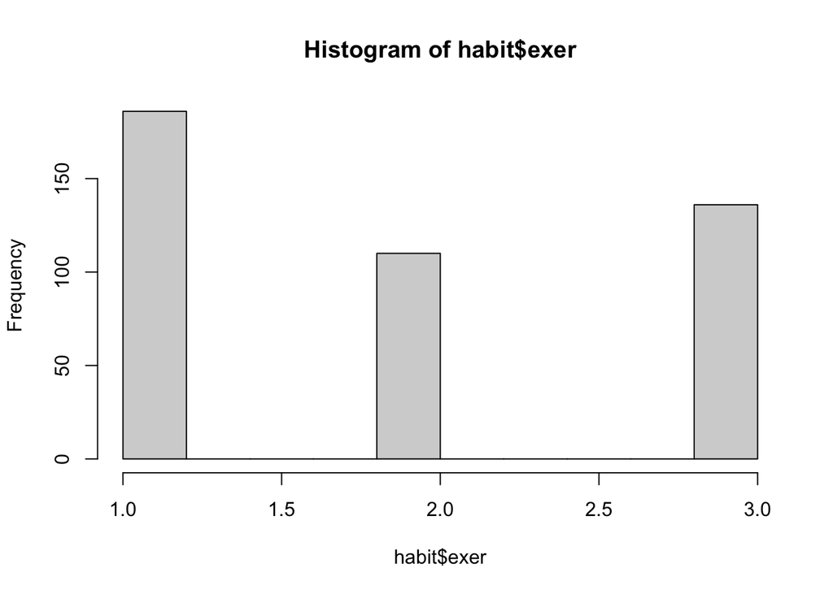

```r
hist(habit$exer)
```

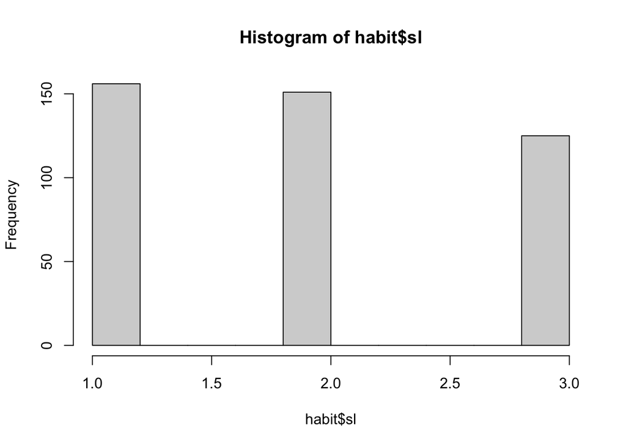

```r
hist(habit$sl)
```

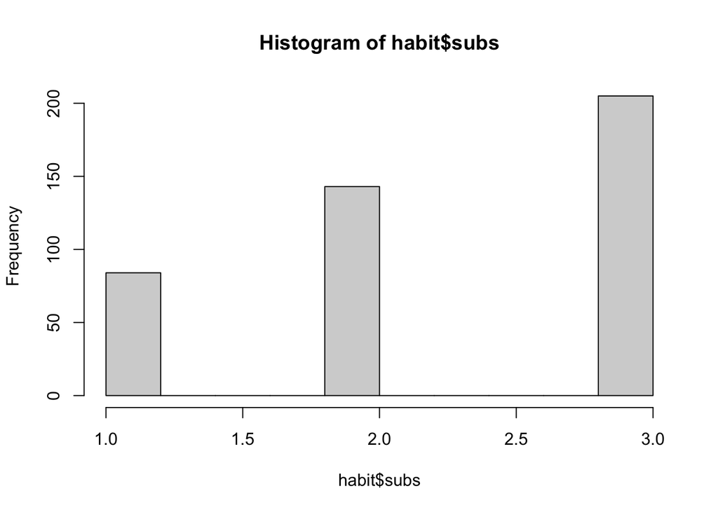

```r
hist(habit$subs)
```

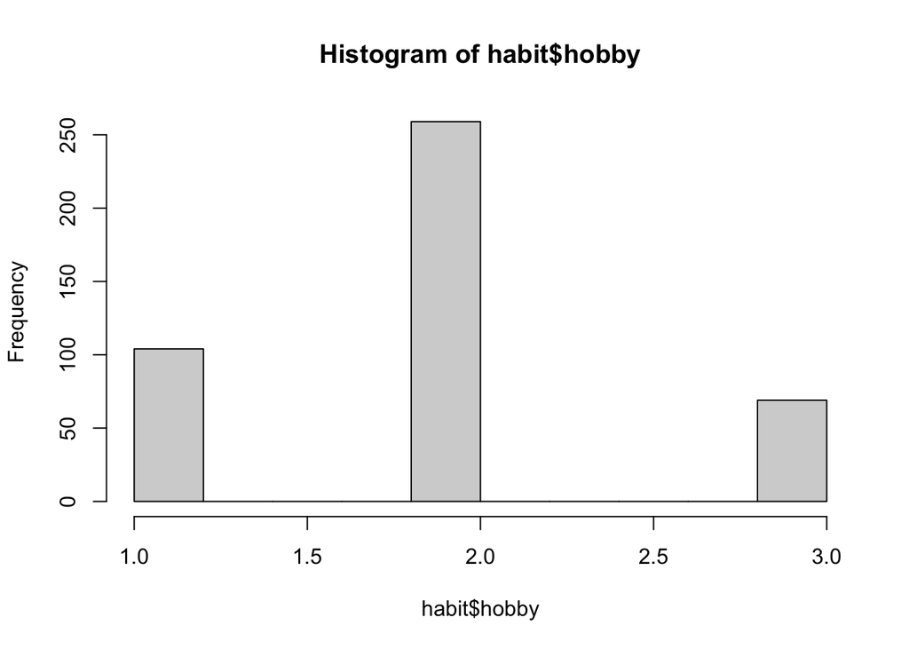

```r
hist(habit$hobby)
```

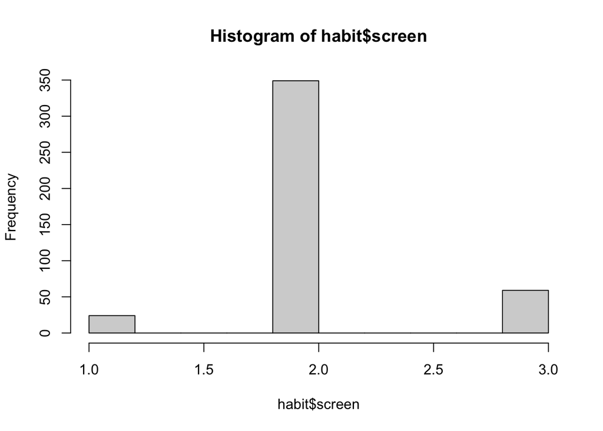

```r
hist(habit$screen)
```

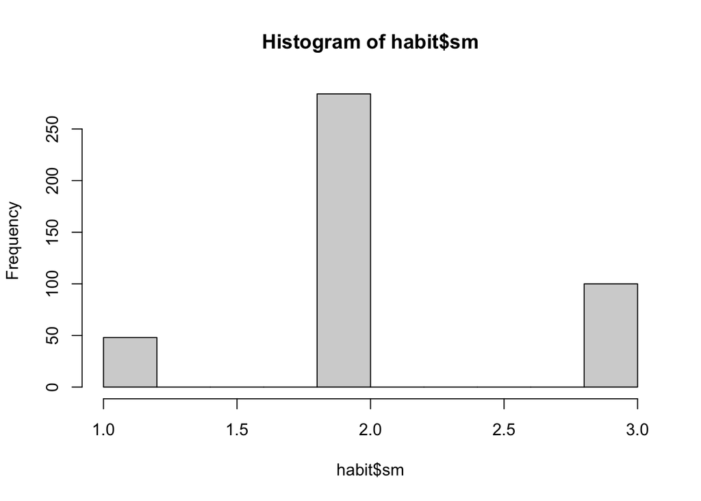

```r
hist(habit$sm)
```

To demonstrate how variables can influence model fit due to estimator assumptions, let’s start by treating these variables as continuous and use ML estimator.

## Model 1

```r
habit.sem <- "beh =~ subs + exer + sl
          leisure =~ sm + screen + hobby
          "
```

```r
cont.fit <- sem(model = habit.sem, data = habit, estimator = "ML",
    missing = "FIML")
summary(cont.fit, fit.measures = TRUE, standardized = TRUE)
```

```
## lavaan 0.6-18 ended normally after 71 iterations
##
##   Estimator                                         ML
##   Optimization method                           NLMINB
##   Number of model parameters                        19
##
##   Number of observations                           432
##   Number of missing patterns                         1
##
## Model Test User Model:
##
##   Test statistic                                30.474
##   Degrees of freedom                                 8
##   P-value (Chi-square)                           0.000
##
## Model Test Baseline Model:
##
##   Test statistic                               118.439
##   Degrees of freedom                                15
##   P-value                                        0.000
##
## User Model versus Baseline Model:
##
##   Comparative Fit Index (CFI)                    0.783
##   Tucker-Lewis Index (TLI)                       0.593
##
##   Robust Comparative Fit Index (CFI)             0.783
##   Robust Tucker-Lewis Index (TLI)                0.593
##
## Loglikelihood and Information Criteria:
##
##   Loglikelihood user model (H0)              -2552.352
##   Loglikelihood unrestricted model (H1)      -2537.115
##
##   Akaike (AIC)                                5142.703
##   Bayesian (BIC)                              5220.003
##   Sample-size adjusted Bayesian (SABIC)       5159.708
##
## Root Mean Square Error of Approximation:
##
```

[output cut: 42 more lines]

```
##    .sl                1.928    0.039   49.890    0.000    1.928    2.400
##    .sm                2.120    0.028   76.939    0.000    2.120    3.702
##    .screen            2.081    0.021  100.408    0.000    2.081    4.831
##    .hobby             1.919    0.030   63.551    0.000    1.919    3.058
##
## Variances:
##                    Estimate  Std.Err  z-value  P(>|z|)   Std.lv  Std.all
##    .subs              0.558    0.041   13.477    0.000    0.558    0.946
##    .exer              0.660    0.052   12.682    0.000    0.660    0.901
##    .sl                0.590    0.049   12.059    0.000    0.590    0.914
##    .sm                0.269    0.025   10.685    0.000    0.269    0.818
##    .screen            0.147    0.015    9.704    0.000    0.147    0.793
##    .hobby             0.338    0.029   11.515    0.000    0.338    0.857
##     beh               0.032    0.021    1.526    0.127    1.000    1.000
##     leisure           0.060    0.022    2.771    0.006    1.000    1.000
```

The first problem we get is a non-positive definite covariance matrix and a suggestion to use lavInspect(cont.fit, “cov.lv”) to investigate the issue. Besides the fact that these covariances and variances are small, this suggestion wasn’t very helpful.

```r
lavInspect(cont.fit, "cov.lv")
```

```
##           beh leisur
## beh     0.032
## leisure 0.047  0.060
```

```r
lavResiduals(cont.fit)
```

```
## $type
## [1] "cor.bentler"
##
## $cov
##          subs   exer     sl     sm screen  hobby
## subs    0.000
## exer   -0.070  0.000
## sl      0.080 -0.003  0.000
## sm      0.079  0.007  0.010  0.000
## screen -0.029  0.003 -0.094  0.029  0.000
## hobby  -0.058  0.022  0.075 -0.102  0.058  0.000
##
## $mean
##   subs   exer     sl     sm screen  hobby
##      0      0      0      0      0      0
##
## $cov.z
##          subs   exer     sl     sm screen  hobby
## subs    0.000
## exer   -2.138  0.000
## sl      1.948 -0.109  0.000
## sm      2.157  0.218  0.319  0.000
## screen -1.019  0.116 -4.038  1.262  0.000
## hobby  -1.697  0.658  2.075 -4.517  1.986  0.000
##
## $mean.z
##   subs   exer     sl     sm screen  hobby
##      0      0      0      0      0      0
##
## $summary
##                            cov mean  total
## srmr                     0.050 0.00  0.044
## srmr.se                  0.007   NA  0.006
## srmr.exactfit.z          3.433   NA  3.433
## srmr.exactfit.pvalue     0.000   NA  0.000
## usrmr                    0.042 0.00  0.037
## usrmr.se                 0.010   NA  0.009
## usrmr.ci.lower           0.026   NA  0.023
## usrmr.ci.upper           0.059   NA  0.052
## usrmr.closefit.h0.value  0.050 0.05  0.050
## usrmr.closefit.z        -0.741   NA -1.401
## usrmr.closefit.pvalue    0.771   NA  0.919
```

Instead, check the output. Fist, you’ll notice that fit is poor. Second, we have very small loadings on all categorical latent variables. Third, and most important, we have a correlation larger than 1 for the two latent variables, which you can see in this line:

```
             Estimate  Std.Err  z-value  P(>|z|)   Std.lv  Std.all
```

Covariances: Estimate Std.Err z-value P(>|z|) Std.lv Std.all beh ~~  
leisure 0.047 0.018 2.572 0.010 1.080 1.080

Recall that Estimate refers to the unstandardized estimate (i.e., covariance) and that Std.all refers to the standardized estimate when both X1 and X2Y are standardized (i.e., correlation). We know this is an indication of problems with the model. The most likely reason is that we’re using ML and violating its assumption of normality because our data is categorical (and most certainly not normal).

# Model 2

Instead, let’s estimate this model by treating these variables as categorical. The model statement is the same, we only need to make changes to the estimation part by adding “ordered” to the sem() command. Recall that: - lavaan cannot use FIML with categorical data - lavaan cannot handle nominal data, so we’re treating our variables as ordinal for demonstration - In Mplus, we could use WLSMV or MLR with categorical data. Only WLSMV is available in lavaan.

```r
cat.fit <- sem(model = habit.sem, data = habit, estimator = "WLSMV",
    ordered = c("sl", "exer", "subs", "sm", "screen", "hobby"))
summary(cat.fit, fit.measures = TRUE, standardized = TRUE)
```

```
## lavaan 0.6-18 ended normally after 38 iterations
##
##   Estimator                                       DWLS
##   Optimization method                           NLMINB
##   Number of model parameters                        19
##
##   Number of observations                           432
##
## Model Test User Model:
##                                               Standard      Scaled
##   Test Statistic                                28.947      34.747
##   Degrees of freedom                                 8           8
##   P-value (Chi-square)                           0.000       0.000
##   Scaling correction factor                                  0.841
##   Shift parameter                                            0.344
##     simple second-order correction
##
## Model Test Baseline Model:
##
##   Test statistic                               185.315     167.141
##   Degrees of freedom                                15          15
##   P-value                                        0.000       0.000
##   Scaling correction factor                                  1.119
##
## User Model versus Baseline Model:
##
##   Comparative Fit Index (CFI)                    0.877       0.824
##   Tucker-Lewis Index (TLI)                       0.769       0.670
##
##   Robust Comparative Fit Index (CFI)                         0.747
##   Robust Tucker-Lewis Index (TLI)                            0.526
##
## Root Mean Square Error of Approximation:
##
##   RMSEA                                          0.078       0.088
##   90 Percent confidence interval - lower         0.049       0.059
##   90 Percent confidence interval - upper         0.109       0.119
##   P-value H_0: RMSEA <= 0.050                    0.058       0.016
##   P-value H_0: RMSEA >= 0.080                    0.493       0.702
##
```

[output cut: 43 more lines]

```
##     screen|t1        -1.593    0.098  -16.191    0.000   -1.593   -1.593
##     screen|t2         1.096    0.076   14.499    0.000    1.096    1.096
##     hobby|t1         -0.704    0.066  -10.644    0.000   -0.704   -0.704
##     hobby|t2          0.996    0.073   13.712    0.000    0.996    0.996
##
## Variances:
##                    Estimate  Std.Err  z-value  P(>|z|)   Std.lv  Std.all
##    .subs              0.916                               0.916    0.916
##    .exer              0.875                               0.875    0.875
##    .sl                0.884                               0.884    0.884
##    .sm                0.768                               0.768    0.768
##    .screen            0.677                               0.677    0.677
##    .hobby             0.802                               0.802    0.802
##     beh               0.084    0.044    1.922    0.055    1.000    1.000
##     leisure           0.232    0.064    3.643    0.000    1.000    1.000
```

The model still has serious problems, which is not surprising given that the levels of these categorical variables are not ordered. Still, you can see some changes in the fit indices simply because of the estimator being used and how we’re treating our variables.

Let’s go with a simpler model. In this one, which can be estimated without errors regardless of the estimator we choose (I had to pick some variables that had similar distributions for this to work), the fit is more clearly different when we use an estimator that does not vs. does accommodate deviations from normality.

```r
habit.sem2 <- "beh =~ exer + sl + subs + work
          "
```

```r
cont.fit1 <- sem(model = habit.sem2, data = habit, estimator = "ML")

summary(cont.fit1, fit.measures = TRUE, standardized = TRUE)
```

```
## lavaan 0.6-18 ended normally after 29 iterations
##
##   Estimator                                         ML
##   Optimization method                           NLMINB
##   Number of model parameters                         8
##
##   Number of observations                           432
##
## Model Test User Model:
##
##   Test statistic                                 6.188
##   Degrees of freedom                                 2
##   P-value (Chi-square)                           0.045
##
## Model Test Baseline Model:
##
##   Test statistic                                45.174
##   Degrees of freedom                                 6
##   P-value                                        0.000
##
## User Model versus Baseline Model:
##
##   Comparative Fit Index (CFI)                    0.893
##   Tucker-Lewis Index (TLI)                       0.679
##
## Loglikelihood and Information Criteria:
##
##   Loglikelihood user model (H0)              -2082.439
##   Loglikelihood unrestricted model (H1)      -2079.345
##
##   Akaike (AIC)                                4180.877
##   Bayesian (BIC)                              4213.425
##   Sample-size adjusted Bayesian (SABIC)       4188.037
##
## Root Mean Square Error of Approximation:
##
##   RMSEA                                          0.070
##   90 Percent confidence interval - lower         0.009
##   90 Percent confidence interval - upper         0.135
##   P-value H_0: RMSEA <= 0.050                    0.228
```

[output cut: 12 more lines]

```
## Latent Variables:
##                    Estimate  Std.Err  z-value  P(>|z|)   Std.lv  Std.all
##   beh =~
##     exer              1.000                               0.281    0.328
##     sl                0.914    0.309    2.955    0.003    0.257    0.320
##     subs              0.507    0.236    2.151    0.031    0.142    0.185
##     work              1.723    0.715    2.409    0.016    0.484    0.574
##
## Variances:
##                    Estimate  Std.Err  z-value  P(>|z|)   Std.lv  Std.all
##    .exer              0.653    0.056   11.572    0.000    0.653    0.892
##    .sl                0.579    0.049   11.800    0.000    0.579    0.898
##    .subs              0.570    0.041   13.948    0.000    0.570    0.966
##    .work              0.475    0.103    4.599    0.000    0.475    0.670
##     beh               0.079    0.041    1.902    0.057    1.000    1.000
```

```r
cat.fit1 <- sem(model = habit.sem2, data = habit, estimator = "WLSMV",
    ordered = c("sl", "subs", "exer", "work"))

summary(cat.fit1, fit.measures = TRUE, standardized = TRUE)
```

```
## lavaan 0.6-18 ended normally after 23 iterations
##
##   Estimator                                       DWLS
##   Optimization method                           NLMINB
##   Number of model parameters                        12
##
##   Number of observations                           432
##
## Model Test User Model:
##                                               Standard      Scaled
##   Test Statistic                                 5.216       6.436
##   Degrees of freedom                                 2           2
##   P-value (Chi-square)                           0.074       0.040
##   Scaling correction factor                                  0.812
##   Shift parameter                                            0.011
##     simple second-order correction
##
## Model Test Baseline Model:
##
##   Test statistic                                53.255      51.214
##   Degrees of freedom                                 6           6
##   P-value                                        0.000       0.000
##   Scaling correction factor                                  1.045
##
## User Model versus Baseline Model:
##
##   Comparative Fit Index (CFI)                    0.932       0.902
##   Tucker-Lewis Index (TLI)                       0.796       0.706
##
##   Robust Comparative Fit Index (CFI)                         0.895
##   Robust Tucker-Lewis Index (TLI)                            0.686
##
## Root Mean Square Error of Approximation:
##
##   RMSEA                                          0.061       0.072
##   90 Percent confidence interval - lower         0.000       0.013
##   90 Percent confidence interval - upper         0.128       0.137
##   P-value H_0: RMSEA <= 0.050                    0.298       0.212
##   P-value H_0: RMSEA >= 0.080                    0.387       0.491
##
```

[output cut: 28 more lines]

```
##     exer|t2           0.482    0.063    7.656    0.000    0.482    0.482
##     sl|t1            -0.355    0.062   -5.754    0.000   -0.355   -0.355
##     sl|t2             0.555    0.064    8.693    0.000    0.555    0.555
##     subs|t1          -0.862    0.069  -12.440    0.000   -0.862   -0.862
##     subs|t2           0.064    0.060    1.057    0.290    0.064    0.064
##     work|t1           0.058    0.060    0.961    0.337    0.058    0.058
##     work|t2           0.653    0.065    9.999    0.000    0.653    0.653
##
## Variances:
##                    Estimate  Std.Err  z-value  P(>|z|)   Std.lv  Std.all
##    .exer              0.867                               0.867    0.867
##    .sl                0.848                               0.848    0.848
##    .subs              0.948                               0.948    0.948
##    .work              0.588                               0.588    0.588
##     beh               0.133    0.065    2.044    0.041    1.000    1.000
```

We have something different in this output: Thresholds: Estimate Std.Err z-value P(>|z|) Std.lv Std.all exer|t1 -0.175 0.061 -2.882 0.004 -0.175 -0.175 exer|t2 0.482 0.063 7.656 0.000 0.482 0.482

Thresholds are the logit/probit values of a latent value that separate between being in category 1 and category 2, category 2 and category 3, and so on. There will always be one fewer threshold than the number of levels of the variable. These are like cut-off points or boundaries between different levels of the categorical variable.

Compare the thresholds for subs and work. You can see that the level of the latent variable for going from category 1 (decreased) to category 2 (no change) is much lower for substance use than for work. You can also see that the level for going from category 2 (no change) to category 3 (increased) is much higher for work than for substance use. In other words, an average participant, who would have a latent variable score of 0 (the mean), would more likely indicate that their substance did not change and that their work productivity decreased.

# A brief practice - model interpretation

For practice, let’s add to the previous model. In this new model, we want to test whether self-regulation (see scripts from a couple of labs ago if needed) predicts behavior change from pre-to-during the pandemic. Do not worry about theory, focus on the values and what you know about latent variables and regression.

How would you interpret the latent factor for behavior (or the Y variable)? Tip: consider the direction of the indicators and whether higher values are better or worse for health, consider how you’d name this variable or describe it on a manuscript (“higher values on this latent variable reflect…”)

```r
practice.sem1 <- "
          # latent factor for behavior
          beh =~ exer + sl + subs + work
          sreg =~ init + inhib + cont + bfi
          beh ~ sreg
          "
```

```r
practice1 <- sem(model = practice.sem1, data = habit, estimator = "WLSMV",
    ordered = c("sl", "subs", "exer", "work"))

summary(practice1, fit.measures = TRUE, standardized = TRUE)
```

```
## lavaan 0.6-18 ended normally after 37 iterations
##
##   Estimator                                       DWLS
##   Optimization method                           NLMINB
##   Number of model parameters                        25
##
##   Number of observations                           432
##
## Model Test User Model:
##                                               Standard      Scaled
##   Test Statistic                                23.307      32.884
##   Degrees of freedom                                19          19
##   P-value (Chi-square)                           0.224       0.025
##   Scaling correction factor                                  0.804
##   Shift parameter                                            3.893
##     simple second-order correction
##
## Model Test Baseline Model:
##
##   Test statistic                               548.969     380.232
##   Degrees of freedom                                28          28
##   P-value                                        0.000       0.000
##   Scaling correction factor                                  1.479
##
## User Model versus Baseline Model:
##
##   Comparative Fit Index (CFI)                    0.992       0.961
##   Tucker-Lewis Index (TLI)                       0.988       0.942
##
##   Robust Comparative Fit Index (CFI)                            NA
##   Robust Tucker-Lewis Index (TLI)                               NA
##
## Root Mean Square Error of Approximation:
##
##   RMSEA                                          0.023       0.041
##   90 Percent confidence interval - lower         0.000       0.015
##   90 Percent confidence interval - upper         0.050       0.064
##   P-value H_0: RMSEA <= 0.050                    0.947       0.709
##   P-value H_0: RMSEA >= 0.080                    0.000       0.002
##
```

[output cut: 50 more lines]

```
##     work|t1           0.058    0.060    0.961    0.337    0.058    0.058
##     work|t2           0.653    0.065    9.999    0.000    0.653    0.653
##
## Variances:
##                    Estimate  Std.Err  z-value  P(>|z|)   Std.lv  Std.all
##    .exer              0.905                               0.905    0.905
##    .sl                0.932                               0.932    0.932
##    .subs              0.946                               0.946    0.946
##    .work              0.301                               0.301    0.301
##    .init              0.334    0.036    9.222    0.000    0.334    0.356
##    .inhib             0.352    0.027   13.109    0.000    0.352    0.726
##    .cont              0.295    0.025   11.741    0.000    0.295    0.529
##    .bfi               0.157    0.019    8.100    0.000    0.157    0.316
##    .beh               0.087    0.047    1.871    0.061    0.916    0.916
##     sreg              0.605    0.082    7.421    0.000    1.000    1.000
```

If you’re not confused yet, consider: what does the observed effect of self-regulation (X) on behavior (Y) mean? Tip: Try to interpret it as you would interpret the results of a regression (e.g., a one unit increase in X means a ___ unit increase/decrease in ___)

Finally, the model seems to fit the data well, but is it useful?